# **Projecto de análises de dados para depósitos aluvionares**

# Vocabulário

| *KPIs* | Significado |
| --- | --- |
| **Volume** | Volume processado (Processed Volume) |
| **Np** | Número de pedra(Number of Stone) |
| **Qts** | Quilates (Caracts) |
| **Teor** | Grade |
| **Tp** | Tamanho médio das pedras(Stone Size) |

### **Primeria Tarefa:**

- Importar a base de dados.

```python
import pandas as pd
import numpy as np
import seaborn as srn
import matplotlib.pyplot as plt
import matplotlib.patches as mpatches
# Use the inline backend to generate the plots within the browser
%matplotlib inline
from scipy import stats
from sklearn.model_selection import train_test_split
from sklearn.linear_model import LinearRegression
from sklearn.linear_model import Ridge
from sklearn.preprocessing import PolynomialFeatures
from sklearn.preprocessing import StandardScaler
from sklearn.pipeline import Pipeline
from sklearn.metrics import r2_score
from sklearn.model_selection import cross_val_score
from tqdm import tqdm
import joblib
import warnings
warnings.filterwarnings('ignore')
```

```python
df = pd.read_csv('NP.csv')
df = pd.DataFrame(df)
```

### **Segunda Tarefa**:

- Pre-processamento dos dados

```python
len(df)
```

```
45
```

```python
df.replace('?', np.nan, inplace=True)
```

```python
missing_data = df.isnull()
```

```python
for column in missing_data.columns.values.tolist():
    print(column)
    print(missing_data[column].value_counts())
```

```
Volume
Volume
False    45
Name: count, dtype: int64
Np
Np
False    45
Name: count, dtype: int64
Qts
Qts
False    45
Name: count, dtype: int64
Teor
Teor
False    45
Name: count, dtype: int64
Tp
Tp
False    45
Name: count, dtype: int64
Deposito
Deposito
False    45
Name: count, dtype: int64
```

```python
df.dtypes
```

```
Volume        int64
Np            int64
Qts         float64
Teor        float64
Tp          float64
Deposito     object
dtype: object
```

```python
df.info(verbose=False)
```

```
<class 'pandas.core.frame.DataFrame'>
RangeIndex: 45 entries, 0 to 44
Columns: 6 entries, Volume to Deposito
dtypes: float64(3), int64(2), object(1)
memory usage: 2.2+ KB
```

```python
df.info()
```

```
<class 'pandas.core.frame.DataFrame'>
RangeIndex: 45 entries, 0 to 44
Data columns (total 6 columns):
 #   Column    Non-Null Count  Dtype
---  ------    --------------  -----
 0   Volume    45 non-null     int64
 1   Np        45 non-null     int64
 2   Qts       45 non-null     float64
 3   Teor      45 non-null     float64
 4   Tp        45 non-null     float64
 5   Deposito  45 non-null     object
dtypes: float64(3), int64(2), object(1)
memory usage: 2.2+ KB
```

```python
desc = pd.DataFrame(index = list(df))
desc['type'] = df.dtypes                                                 # This column stores the data type of each column.
desc['count'] = df.count()                                               # This column stores the number of non-null values in each column.
desc['nunique'] = df.nunique()                                           # This column stores the number of unique values in each column.
desc['%unique'] = desc['nunique'] /len(df) * 100                          # This column stores the percentage of unique values in each column.
desc['null'] = df.isnull().sum()                                         # This column stores the number of null values in each column.
desc['%null'] = desc['null'] / len(df) * 100                             # This column stores the percentage of null values in each column.
desc = pd.concat([desc,df.describe().T.drop('count',axis=1)],axis=1)     # This line concatenates the 'desc' DataFrame with the descriptive statistics of the 'df_house' DataFrame.
desc.sort_values(by=['type','null']).style.background_gradient(cmap='YlOrBr')\
    .bar(subset=['mean'],color='green')\
    .bar(subset=['max'],color='red')\
    .bar(subset=['min'], color='pink')\
    .bar(subset=['std'],color='lightblue')
```

|  | type | count | nunique | %unique | null | %null | mean | std | min | 25% | 50% | 75% | max |
| --- | --- | --- | --- | --- | --- | --- | --- | --- | --- | --- | --- | --- | --- |
| Volume | int64 | 45 | 44 | 97.777778 | 0 | 0.000000 | 1901.666667 | 789.288229 | 248.000000 | 1199.000000 | 2124.000000 | 2492.000000 | 3212.000000 |
| Np | int64 | 45 | 45 | 100.000000 | 0 | 0.000000 | 934.288889 | 993.117512 | 113.000000 | 354.000000 | 654.000000 | 1055.000000 | 5290.000000 |
| Qts | float64 | 45 | 45 | 100.000000 | 0 | 0.000000 | 176.201333 | 118.132506 | 19.160000 | 95.110000 | 147.840000 | 233.820000 | 663.310000 |
| Teor | float64 | 45 | 18 | 40.000000 | 0 | 0.000000 | 0.094444 | 0.055209 | 0.020000 | 0.060000 | 0.080000 | 0.110000 | 0.290000 |
| Tp | float64 | 45 | 24 | 53.333333 | 0 | 0.000000 | 0.241111 | 0.092226 | 0.110000 | 0.180000 | 0.240000 | 0.270000 | 0.530000 |
| Deposito | object | 45 | 4 | 8.888889 | 0 | 0.000000 | nan | nan | nan | nan | nan | nan | nan |

### **Terceira Tarefa**

- Análise de dados exploratória

```python
numeric_df = df.select_dtypes(include=['int64', 'float64'])
```

```python
correlation = numeric_df.corr()
correlation
```

|  | Volume | Np | Qts | Teor | Tp |
| --- | --- | --- | --- | --- | --- |
| Volume | 1.000000 | 0.330758 | 0.453073 | -0.171924 | -0.063182 |
| Np | 0.330758 | 1.000000 | 0.932557 | 0.718891 | -0.544748 |
| Qts | 0.453073 | 0.932557 | 1.000000 | 0.722256 | -0.329128 |
| Teor | -0.171924 | 0.718891 | 0.722256 | 1.000000 | -0.298717 |
| Tp | -0.063182 | -0.544748 | -0.329128 | -0.298717 | 1.000000 |

```python
descritive_1 = numeric_df.describe()
descritive_1
```

|  | Volume | Np | Qts | Teor | Tp |
| --- | --- | --- | --- | --- | --- |
| count | 45.000000 | 45.000000 | 45.000000 | 45.000000 | 45.000000 |
| mean | 1901.666667 | 934.288889 | 176.201333 | 0.094444 | 0.241111 |
| std | 789.288229 | 993.117512 | 118.132506 | 0.055209 | 0.092226 |
| min | 248.000000 | 113.000000 | 19.160000 | 0.020000 | 0.110000 |
| 25% | 1199.000000 | 354.000000 | 95.110000 | 0.060000 | 0.180000 |
| 50% | 2124.000000 | 654.000000 | 147.840000 | 0.080000 | 0.240000 |
| 75% | 2492.000000 | 1055.000000 | 233.820000 | 0.110000 | 0.270000 |
| max | 3212.000000 | 5290.000000 | 663.310000 | 0.290000 | 0.530000 |

```python
categorical_df = df.select_dtypes(include=['object'])
categorical_df.head(5)
```

|  | Deposito |
| --- | --- |
| 0 | TER-LEZ |
| 1 | LEZIRIA |
| 2 | TERRAÇO |
| 3 | TER-FLUVIAL |
| 4 | TERRAÇO |

```python
descritive_2 = categorical_df.describe()
descritive_2
```

|  | Deposito |
| --- | --- |
| count | 45 |
| unique | 4 |
| top | TERRAÇO |
| freq | 15 |

#### **Correlação de Pearson**

```python
pearson_coef, p_value = stats.pearsonr(df.Volume, df.Qts)
print('Pearson Correlation Coefficient:', pearson_coef)
print('P-value:', p_value)
```

```
Pearson Correlation Coefficient: 0.4530729464255103
P-value: 0.0017761016995741761
```

```python
pearson_coef, p_value = stats.pearsonr(df.Np, df.Qts)
print('Pearson Correlation Coefficient:', pearson_coef)
print('P-value:', p_value)
```

```
Pearson Correlation Coefficient: 0.9325568025908745
P-value: 1.2178243790113597e-20
```

```python
pearson_coef, p_value = stats.pearsonr(df.Teor, df.Qts)
print('Pearson Correlation Coefficient:', pearson_coef)
print('P-value:', p_value)
```

```
Pearson Correlation Coefficient: 0.7222557199323529
P-value: 2.137975173519588e-08
```

```python
pearson_coef, p_value = stats.pearsonr(df.Tp, df.Qts)
print('Pearson Correlation Coefficient:', pearson_coef)
print('P-value:', p_value)
```

```
Pearson Correlation Coefficient: -0.329128079585418
P-value: 0.027269369629713193
```

**Conclusão**

A análise estatística revelou insights cruciais sobre os fatores que influenciam a recuperação de quilates em depósitos aluvionares de diamantes.

`Influência do Tamanho das Pedras` (Tp): Apesar de apresentar um coeficiente de correlação negativo e fraco (-0.32), o p-valor de 0.02 indica que essa relação é estatisticamente significativa. Isso sugere que, embora a influência do Tp na recuperação de quilates seja limitada, não pode ser descartada.

`Impacto do Volume Processado` (Volume): Observamos uma correlação positiva moderada (0.45) entre o volume processado e a recuperação de quilates, com um p-valor de 0.0017. Isso confirma que o volume tratado tem um papel relevante, mas não isolado, na recuperação de diamantes.

`Fatores de Maior Impacto:` Np e Teor: Essas variáveis demonstraram uma forte correlação com a recuperação de quilates, com um p-valor altamente significativo. Isso reforça que o número de pedras recuperadas (Np) e o teor médio de diamantes no depósito (Teor) são os principais direcionadores do sucesso operacional na recuperação diamantífera.

`Conclusão Estratégica:` Diante desses resultados, fica evidente que a otimização da recuperação de quilates deve estar fortemente baseada no controle e monitoramento do Np e Teor, enquanto o volume processado deve ser tratado como um fator complementar. Essas descobertas oferecem um suporte valioso para estratégias operacionais mais assertivas e eficientes na mineração aluvionar de diamantes.

[EN]

**Conclusion**

A statistical analysis revealed crucial insights into the factors that influence carat recovery in alluvial diamond deposits.

`Influence of Stone Size` (Tp): Despite presenting a weak negative brightness coefficient (-0.32), the p-value of 0.02 indicates that this relationship is statistically significant. This suggests that, although the influence of Tp on carat recovery is limited, it cannot be ruled out.

`Impact of Processed Volume` (Volume): We observed a moderate positive brightness (0.45) between processed volume and carat recovery, with a p-value of 0.0017. This confirms that the treated volume has a relevant, but not isolated, role in diamond recovery.

`Factors with the Greatest Impact:` Np and Grade: These variations obtained a strong visibility with carat recovery, with a highly significant value. This reinforces that the number of stones recovered (Np) and the average diamond content in the deposit (Grade) are the main drivers of operational success in diamond recovery.

`Strategic Conclusion:` Given these results, it is clear that the optimization of carat recovery should be strongly based on the control and monitoring of Np and Grade, while the volume processed should be treated as a complementary factor. These findings provide valuable support for more assertive and efficient operational strategies in alluvial diamond mining.

### **Volume**

```python
df_volume = df.groupby(["Deposito"])['Volume'].sum().reset_index()
df_volume_S = df.groupby(["Deposito"])['Volume'].sum().reset_index()
df_volume_S.set_index('Deposito', inplace=True)
# df_volume = df_volume.transpose()
df_volume_S
```

| Deposito | Volume |
| --- | --- |
| LEZIRIA | 18976 |
| TER-FLUVIAL | 13765 |
| TER-LEZ | 21390 |
| TERRAÇO | 31444 |

```python
def create_waffle_chart(categories, dataframe, column, values, height, width, colormap, value_sign=''):

    total_values = dataframe[column].sum()
    category_proportions = dataframe[column] / total_values

    total_num_tiles = width * height
    print('Total number of tiles is', total_num_tiles)

    tiles_per_category = (category_proportions * total_num_tiles).round().astype(int)

    for i, tiles in enumerate(tiles_per_category):
        print(categories[i] + ': ' + str(tiles))

    waffle_chart = np.zeros((height, width))

    category_index = 0
    tile_index = 0

    for col in range(width):
        for row in range(height):
            tile_index += 1

            if tile_index > sum(tiles_per_category[0:category_index]):
                category_index += 1

            waffle_chart[row, col] = category_index

    fig = plt.figure()

    plt.matshow(waffle_chart, cmap=colormap)
    plt.colorbar()

    ax = plt.gca()

    ax.set_xticks(np.arange(-.5, (width), 1), minor=True)
    ax.set_yticks(np.arange(-.5, (height), 1), minor=True)

    ax.grid(which='minor', color='w', linestyle='-', linewidth=2)

    plt.xticks([])
    plt.yticks([])

    values_cumsum = np.cumsum(values)
    total_values = values_cumsum[len(values_cumsum) - 1]

    legend_handles = []
    for i, category in enumerate(categories):
        if value_sign == '%':
            label_str = category + '(' + str(values[i]) + value_sign + ')'
        else:
            label_str = category + '(' + value_sign + str(values[i]) + ')'

        color_val = colormap(float(values_cumsum[i])/total_values)
        legend_handles.append(mpatches.Patch(color=color_val, label=label_str))

    plt.legend(
        handles=legend_handles,
        loc='lower center',
        ncol=len(categories),
        bbox_to_anchor=(0., -0.2, 0.95, .1))

    plt.show()
```

```
Total number of tiles is 400
LEZIRIA: 89
TER-FLUVIAL: 64
TER-LEZ: 100
TERRAÇO: 147
```

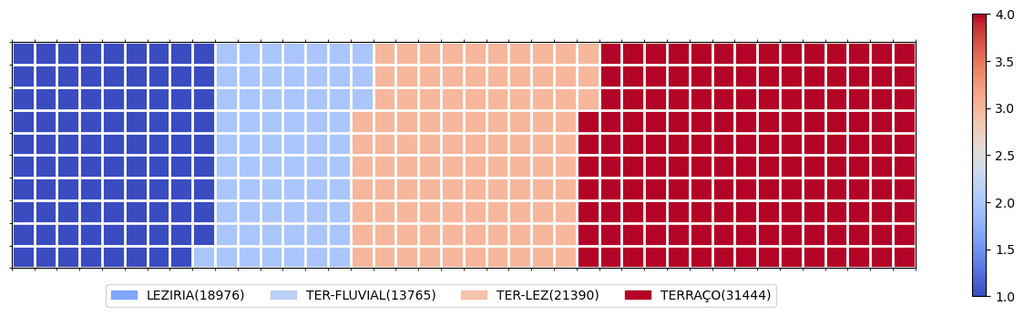

```python
width = 40 # width of chart
heigth = 10 # heigth chart
dataframe = df_volume_S
column = 'Volume'

categories = df_volume_S.index.values  # categories
values = df_volume_S['Volume']         # corresponding values of categories

colormap = plt.cm.coolwarm       # Color map class


create_waffle_chart(categories, dataframe, column, values, heigth, width, colormap)
```

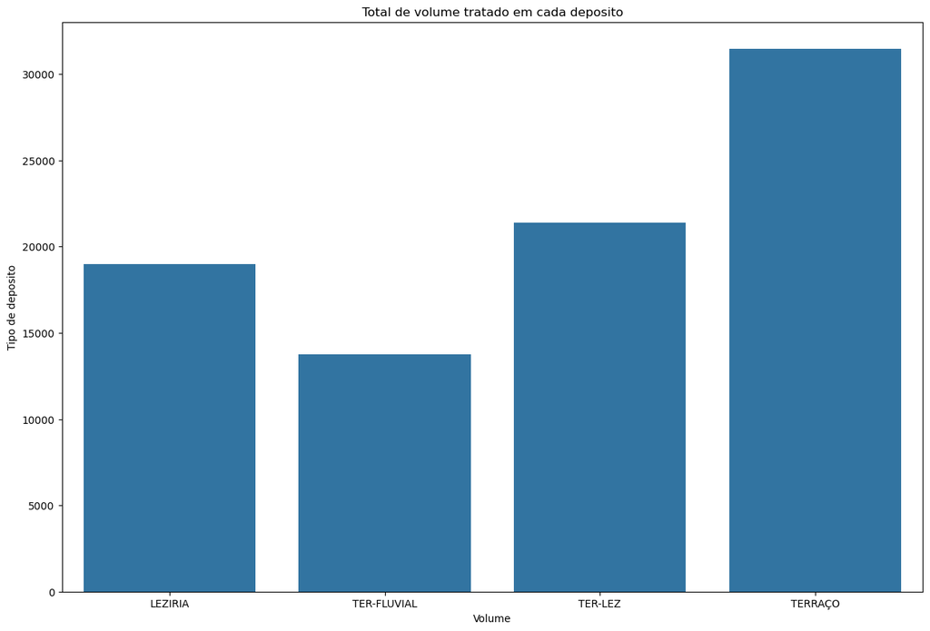

```python
plt.figure(figsize=(15, 10))
srn.barplot(x='Deposito', y='Volume', data=df_volume_S)

plt.title('Total de volume tratado em cada deposito')
plt.xlabel('Volume')
plt.ylabel('Tipo de deposito')

plt.show()
```

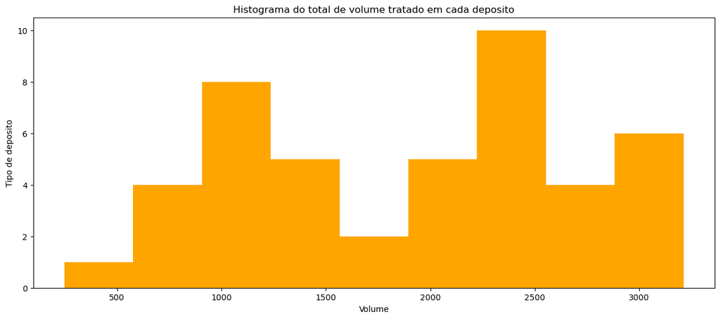

```python
df['Volume'].plot(kind='hist', color='orange', bins=9, figsize=(15, 6))

plt.title('Histograma do total de volume tratado em cada deposito')
plt.xlabel('Volume')
plt.ylabel('Tipo de deposito')

plt.show()
```

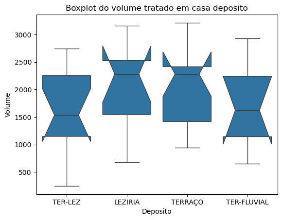

```python
# Boxplot para as colunas 'Deposito' e 'Volume'.
df['Deposito'].unique()

srn.boxplot(
            x='Deposito',
            y='Volume',
            data=df,
            orient='v',
            #color='orange',
            notch=True).set_title('Boxplot do volume tratado em casa deposito')

plt.show()
```

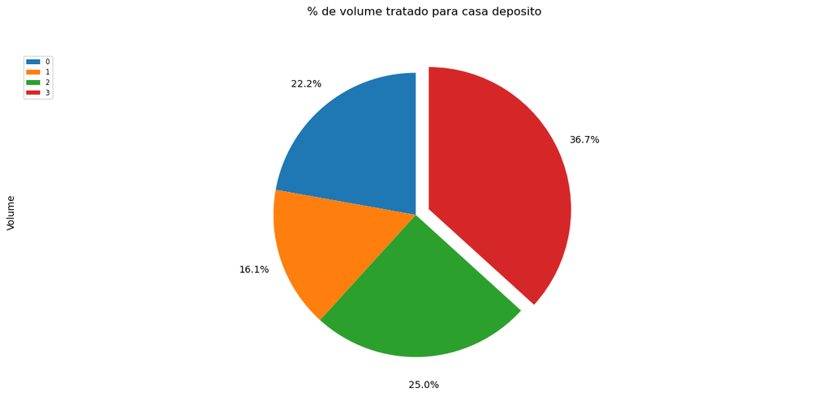

```python
color_list = ['gold', 'yellowgreen', 'blue', 'lightskyblue']

explode_list = [0, 0, 0, 0.1]

df_volume_S['Volume'].plot(kind='pie',
                            figsize=(15, 6),
                            autopct='%1.1f%%',
                            startangle=90,
                            #shadow=True,
                            labels=None,
                            pctdistance=1.20,
                            explode=explode_list
                            )


# scale the title up by 12% to match pctdistance
plt.title(' % de volume tratado para casa deposito', y=1.10)

# Sets the pie chart to look like a circle.
plt.axis('equal')

# Add legend
plt.legend(labels=df_volume.index, loc='upper left', fontsize=7)

plt.show()
```

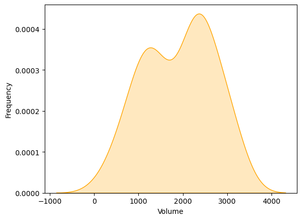

```python
srn.kdeplot(df.Volume, shade=True, color='orange')
plt.ylabel('Frequency')
plt.xlabel('Volume')

plt.show()
```

### **Quilates**

```python
df_qts_S = df.groupby(["Deposito"])['Qts'].sum().reset_index().round(2)
df_qts_S.set_index('Deposito', inplace=True)
df_qts_S_mean = df.groupby(["Deposito"])['Qts'].mean().reset_index().round(2)
df_qts_S_mean.set_index('Deposito', inplace=True)
```

```
Total number of tiles is 400
LEZIRIA: 94
TER-FLUVIAL: 78
TER-LEZ: 111
TERRAÇO: 117
```

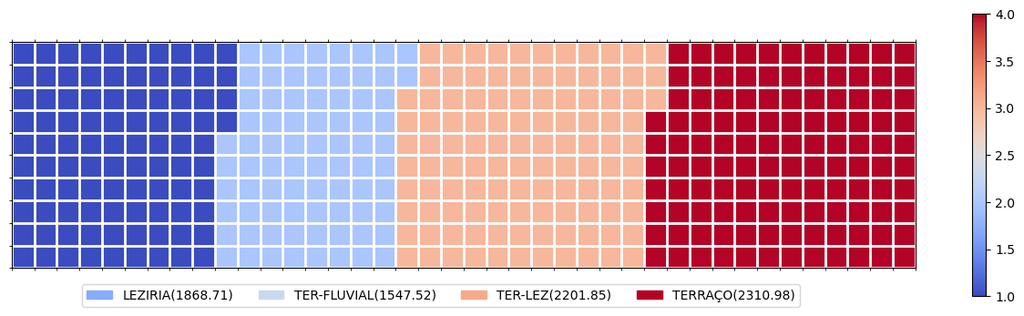

```python
width = 40 # width of chart
heigth = 10 # heigth chart
dataframe = df_qts_S
column = 'Qts'

categories = df_qts_S.index.values  # categories
values = df_qts_S['Qts']         # corresponding values of categories

colormap = plt.cm.coolwarm       # Color map class


create_waffle_chart(categories, dataframe, column, values, heigth, width, colormap)
```

```
Total number of tiles is 400
LEZIRIA: 115
TER-FLUVIAL: 107
TER-LEZ: 94
TERRAÇO: 85
```

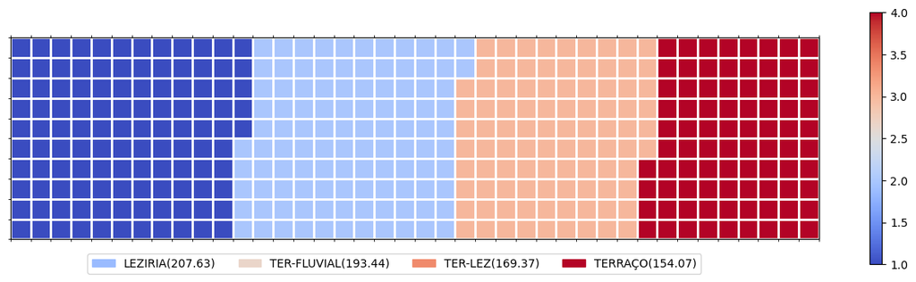

```python
width = 40 # width of chart
heigth = 10 # heigth chart
dataframe = df_qts_S_mean
column = 'Qts'

categories = df_qts_S_mean.index.values  # categories
values = df_qts_S_mean['Qts']          # corresponding values of categories

colormap = plt.cm.coolwarm       # Color map class

create_waffle_chart(categories, dataframe, column, values, heigth, width, colormap)
```

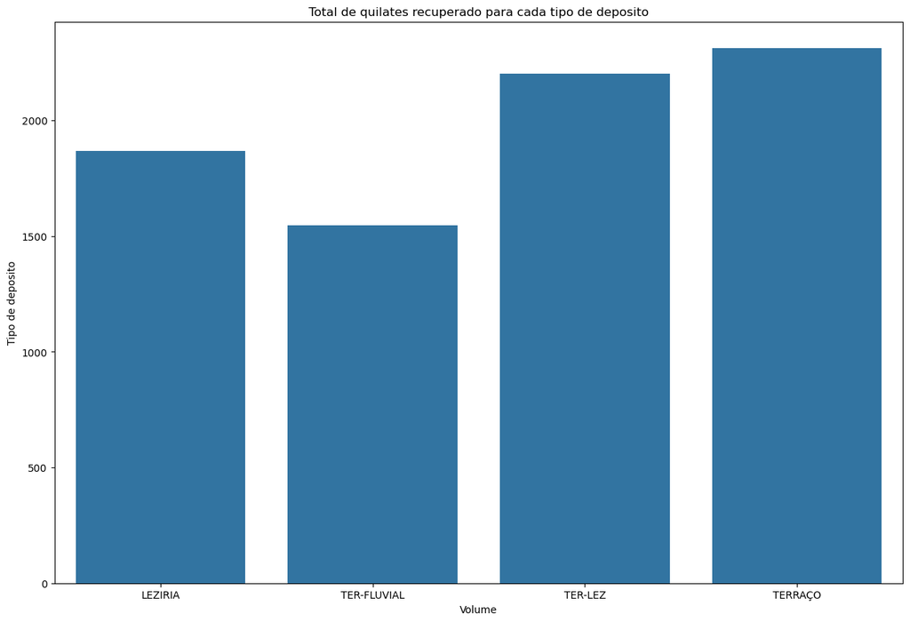

```python
plt.figure(figsize=(15, 10))
srn.barplot(x='Deposito', y='Qts', data=df_qts_S)

plt.title('Total de quilates recuperado para cada tipo de deposito')
plt.xlabel('Volume')
plt.ylabel('Tipo de deposito')

plt.show()
```

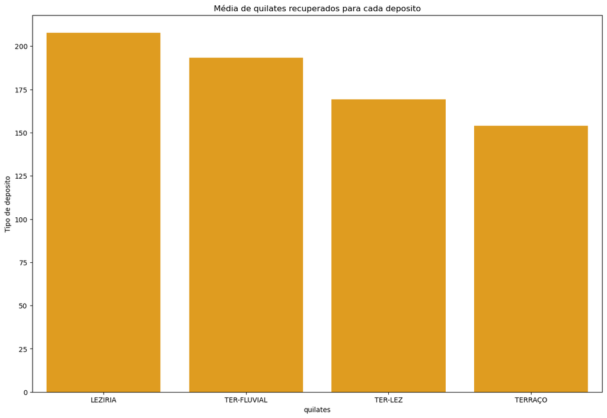

```python
plt.figure(figsize=(15, 10))
srn.barplot(x='Deposito', y='Qts',color='orange', data=df_qts_S_mean)

plt.title('Média de quilates recuperados para cada deposito')
plt.xlabel('quilates')
plt.ylabel('Tipo de deposito')

plt.show()
```

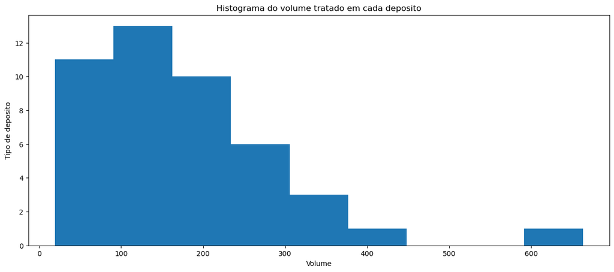

```python
df['Qts'].plot(kind='hist', bins=9, figsize=(15, 6))

plt.title('Histograma do volume tratado em cada deposito')
plt.xlabel('Volume')
plt.ylabel('Tipo de deposito')

plt.show()
```

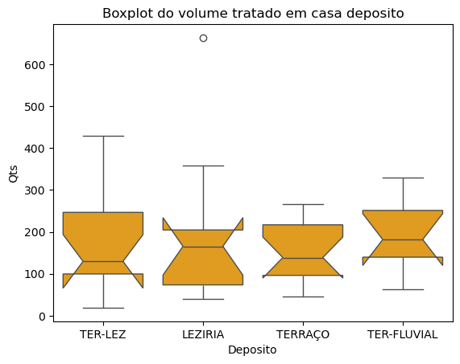

```python
# Boxplot para as colunas 'Deposito' e 'Volume'.
df['Deposito'].unique()

srn.boxplot(
            x='Deposito',
            y='Qts',
            data=df,
            orient='v',
            color='orange',
            notch=True).set_title('Boxplot do volume tratado em casa deposito')

plt.show()
```

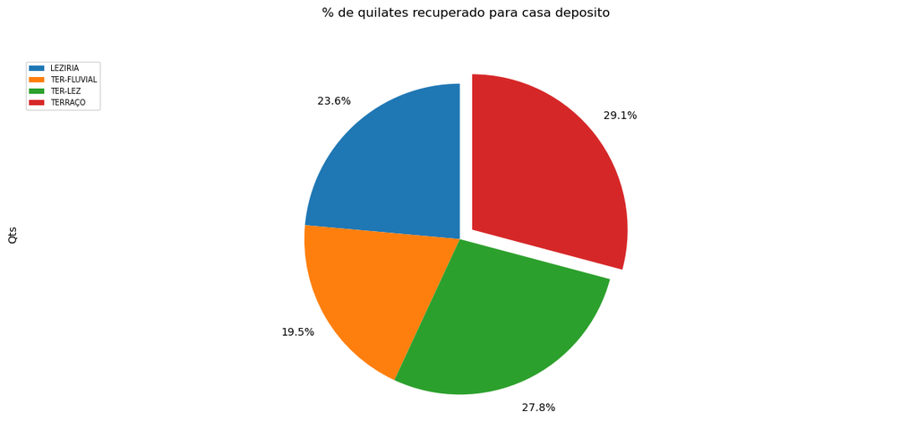

```python
color_list = ['gold', 'yellowgreen', 'blue', 'lightskyblue']

explode_list = [0, 0, 0, 0.1]

df_qts_S['Qts'].plot(kind='pie',
                            figsize=(15, 6),
                            autopct='%1.1f%%',
                            startangle=90,
                            #shadow=True,
                            labels=None,
                            pctdistance=1.20,
                            explode=explode_list
                            )


# scale the title up by 12% to match pctdistance
plt.title('% de quilates recuperado para casa deposito', y=1.10)

# Sets the pie chart to look like a circle.
plt.axis('equal')

# Add legend
plt.legend(labels=df_qts_S.index, loc='upper left', fontsize=7)

plt.show()
```

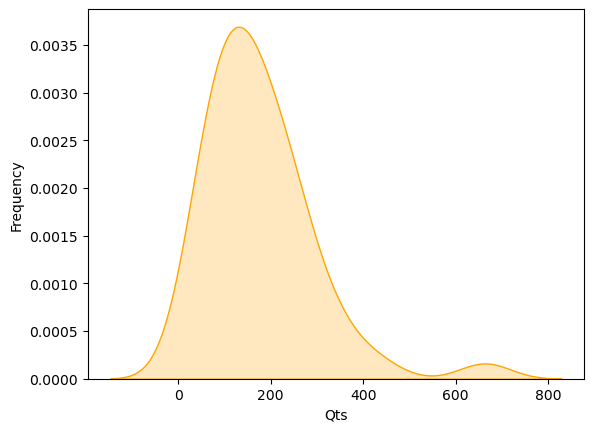

```python
srn.kdeplot(df.Qts, shade=True, color='orange')
plt.ylabel('Frequency')
plt.xlabel('Qts')

plt.show()
```

### **Np**

```python
df_np_S = df.groupby(["Deposito"])['Np'].sum().reset_index().round(2)
df_np_S.set_index('Deposito', inplace=True)
df_np_S_mean = df.groupby(["Deposito"])['Np'].mean().reset_index().round(2)
df_np_S_mean.set_index('Deposito', inplace=True)
```

```
Total number of tiles is 400
LEZIRIA: 108
TER-FLUVIAL: 79
TER-LEZ: 107
TERRAÇO: 106
```

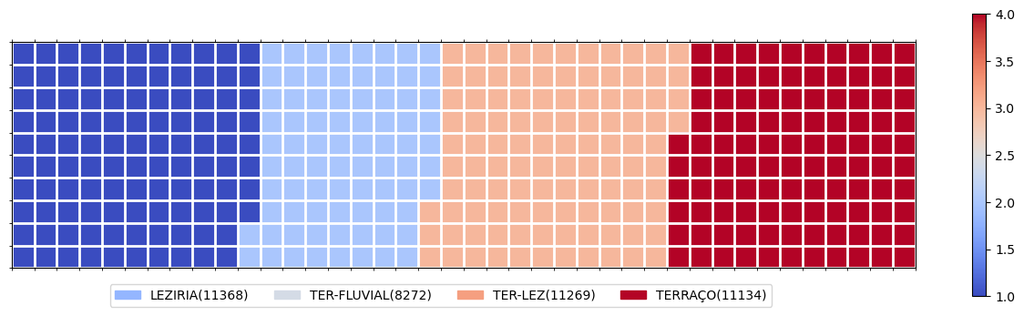

```python
width = 40 # width of chart
heigth = 10 # heigth chart
dataframe = df_np_S
column = 'Np'

categories = df_np_S.index.values  # categories
values = df_np_S['Np']         # corresponding values of categories

colormap = plt.cm.coolwarm       # Color map class


create_waffle_chart(categories, dataframe, column, values, heigth, width, colormap)
```

```
Total number of tiles is 400
LEZIRIA: 129
TER-FLUVIAL: 106
TER-LEZ: 89
TERRAÇO: 76
```

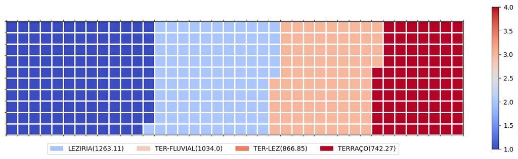

```python
width = 40 # width of chart
heigth = 10 # heigth chart
dataframe = df_np_S_mean
column = 'Np'

categories = df_np_S_mean.index.values  # categories
values = df_np_S_mean['Np']         # corresponding values of categories

colormap = plt.cm.coolwarm       # Color map class


create_waffle_chart(categories, dataframe, column, values, heigth, width, colormap)
```

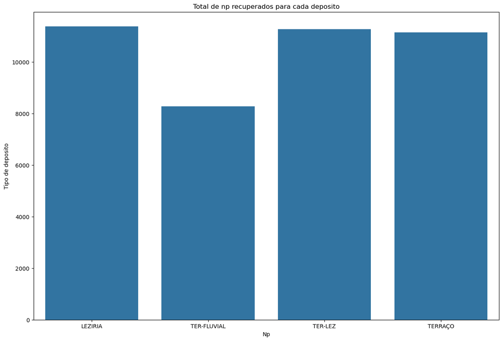

```python
plt.figure(figsize=(15, 10))
srn.barplot(x='Deposito', y='Np', data=df_np_S)

plt.title('Total de np recuperados para cada deposito')
plt.xlabel('Np')
plt.ylabel('Tipo de deposito')

plt.show()
```

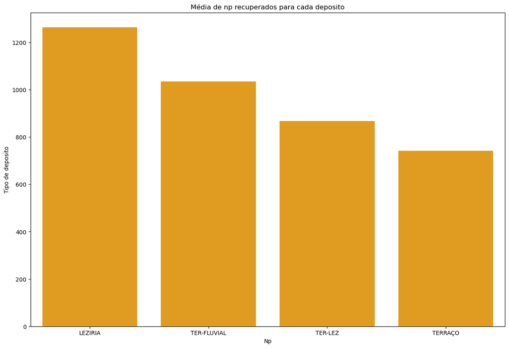

```python
plt.figure(figsize=(15, 10))
srn.barplot(x='Deposito', y='Np', color='orange', data=df_np_S_mean)

plt.title('Média de np recuperados para cada deposito')
plt.xlabel('Np')
plt.ylabel('Tipo de deposito')

plt.show()
```

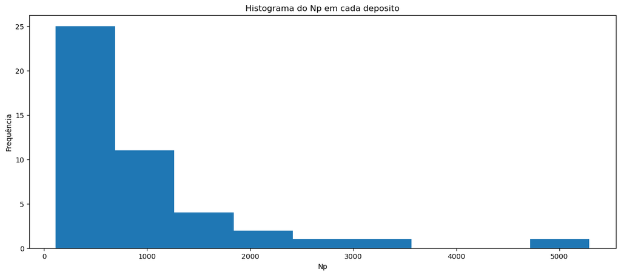

```python
df['Np'].plot(kind='hist', bins=9, figsize=(15, 6))

plt.title('Histograma do Np em cada deposito')
plt.xlabel('Np')
plt.ylabel('Frequência')

plt.show()
```

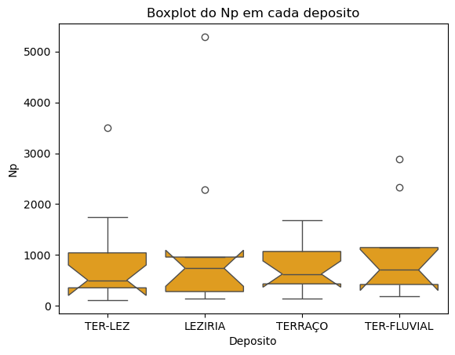

```python
# Boxplot para as colunas 'Deposito' e 'Volume'.
df['Deposito'].unique()

srn.boxplot(x='Deposito',
            y='Np',
            data=df,
            orient='v',
            color='orange',
            notch=True).set_title('Boxplot do Np em cada deposito')

plt.show()
```

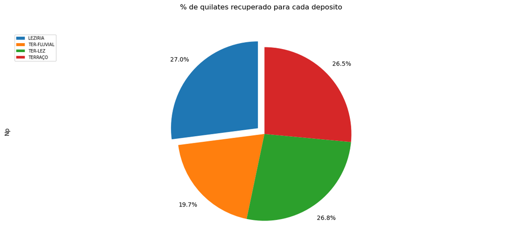

```python
color_list = ['gold', 'yellowgreen', 'blue', 'lightskyblue']

explode_list = [0.1, 0, 0, 0]

df_np_S['Np'].plot(kind='pie',
                            figsize=(15, 6),
                            autopct='%1.1f%%',
                            startangle=90,
                            #shadow=True,
                            labels=None,
                            pctdistance=1.20,
                            explode=explode_list
                            )


# scale the title up by 12% to match pctdistance
plt.title('% de quilates recuperado para cada deposito', y=1.10)

# Sets the pie chart to look like a circle.
plt.axis('equal')

# Add legend
plt.legend(labels=df_np_S.index, loc='upper left', fontsize=7)

plt.show()
```

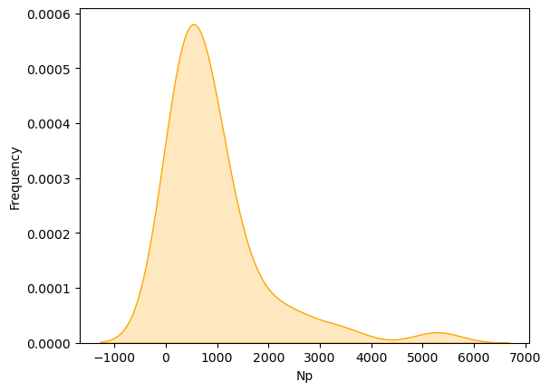

```python
srn.kdeplot(df.Np, shade=True, color='orange')
plt.ylabel('Frequency')
plt.xlabel('Np')

plt.show()
```

### **Teor**

```python
df_teor_mean = df.groupby(["Deposito"])['Teor'].mean().reset_index().round(2)
df_teor_mean.set_index('Deposito', inplace=True)
```

```
Total number of tiles is 400
LEZIRIA: 95
TER-FLUVIAL: 105
TER-LEZ: 105
TERRAÇO: 95
```

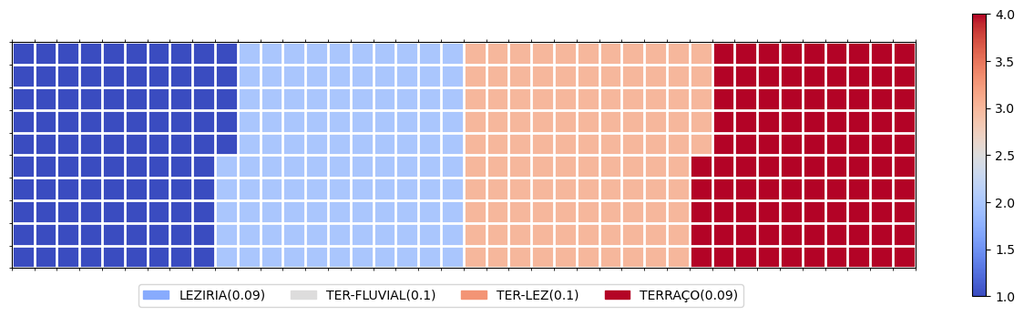

```python
width = 40 # width of chart
heigth = 10 # heigth chart
dataframe = df_teor_mean
column = 'Teor'

categories = df_teor_mean.index.values  # categories
values = df_teor_mean['Teor']         # corresponding values of categories

colormap = plt.cm.coolwarm       # Color map class


create_waffle_chart(categories, dataframe, column, values, heigth, width, colormap)
```

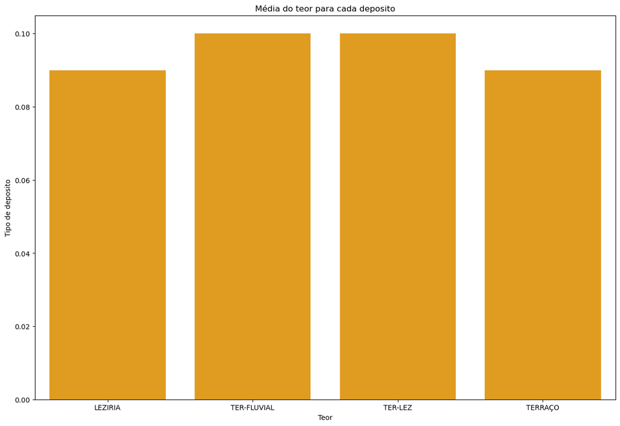

```python
plt.figure(figsize=(15, 10))
srn.barplot(x='Deposito', y='Teor', color='orange', data=df_teor_mean)

plt.title('Média do teor para cada deposito')
plt.xlabel('Teor')
plt.ylabel('Tipo de deposito')

plt.show()
```

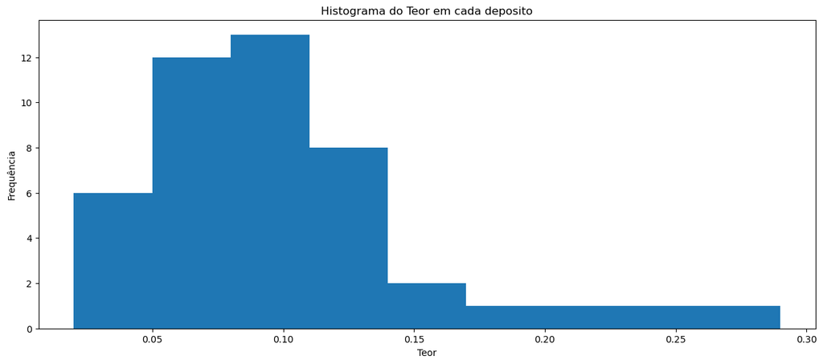

```python
df['Teor'].plot(kind='hist', bins=9, figsize=(15, 6))

plt.title('Histograma do Teor em cada deposito')
plt.xlabel('Teor')
plt.ylabel('Frequência')

plt.show()
```

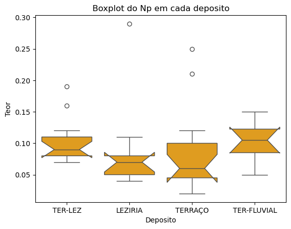

```python
# Boxplot para as colunas 'Deposito' e 'Volume'.
df['Deposito'].unique()

srn.boxplot(x='Deposito',
            y='Teor',
            data=df,
            orient='v',
            color='orange',
            notch=True).set_title('Boxplot do Np em cada deposito')

plt.show()
```

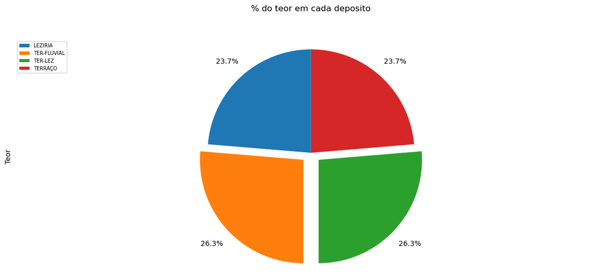

```python
color_list = ['gold', 'yellowgreen', 'blue', 'lightskyblue']

explode_list = [0, 0.1, 0.1, 0]

df_teor_mean['Teor'].plot(kind='pie',
                            figsize=(15, 6),
                            autopct='%1.1f%%',
                            startangle=90,
                            #shadow=True,
                            labels=None,
                            pctdistance=1.20,
                            explode=explode_list
                            )


# scale the title up by 12% to match pctdistance
plt.title('% do teor em cada deposito', y=1.10)

# Sets the pie chart to look like a circle.
plt.axis('equal')

# Add legend
plt.legend(labels=df_teor_mean.index, loc='upper left', fontsize=7)

plt.show()
```

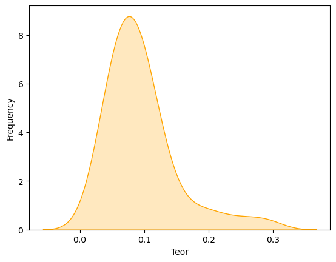

```python
srn.kdeplot(df.Teor, shade=True, color='orange')
plt.ylabel('Frequency')
plt.xlabel('Teor')

plt.show()
```